# AR-MA manual

Diva Nisfu Mustika

# White Noise

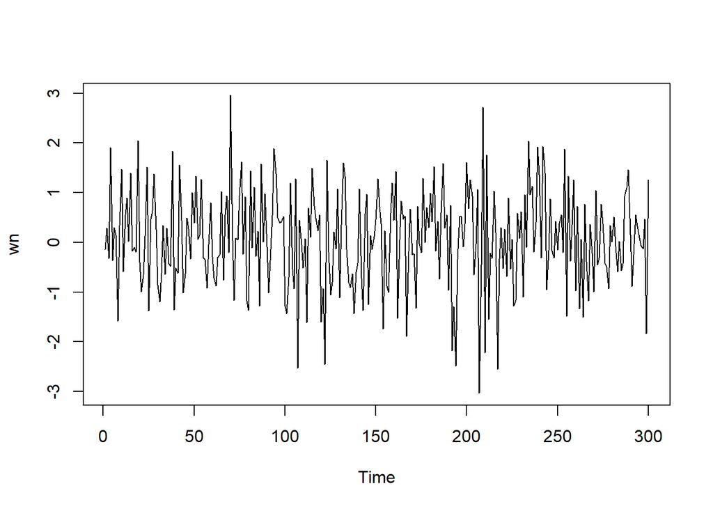

```r
set.seed(1002)
wn <- rnorm(300)
ts.plot(wn)
```

Dapat terlihat bahwa *white noise* tidak memiliki autokorelasi dari ACF. Perhatikan bahwa lag ke-0 adalah korelasi observasi ke-t dengan dirinya sendiri. Nilai korelasi tersebut pasti 1. Sebagai alternatif, lag pertama di plot ACF dapat ditetapkan sebagai 1 (alih-alih 0) dengan menambahkan argumen `xlim(1, lag akhir)`. Plot tersebut dapat disandingkan bersamaan dengan membuat matriks $1 \times 2$ dengan `par(mfrow = c(1,2))`.

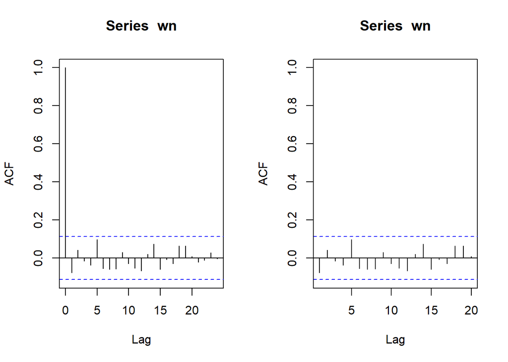

```r
par(mfrow = c(1, 2))
acf(wn)
acf(wn, xlim = c(1, 20))
```

# Proses MA

Proses MA dapat dituliskan sebagai berikut:

$$y_{t} = c + e_t + \theta_{1}e_{t-1} + \theta_{2}e_{t-2} + \dots +
\theta_{q}e_{t-q} = c+{e_t+\sum_{i=1}^p \theta_ie_{t-i}}$$
Terlihat bahwa $e_t$, atau *white noise*, berperan penting dalam pembangkitan proses MA.

## Pembangkitan Proses MA(2)

Akan dicoba membangkitkan proses MA paling sederhana, yaitu MA(2) dengan $\theta_1 = 0.4$ dan $\theta_2 = 0.6$sebanyak 300 observasi dan $c=0$. Karena diperlukan satu nilai awal untuk $e_{t-2}$, masukkan nilai pertama white noise sebagai nilai awal tersebut.

```r
set.seed(1002)
ma<- wn[c(1,2)]
ma
```

```
## [1] -0.1382882  0.2846285
```

Nilai-nilai selanjutnya dapat dicari melalui *loop*. Bentuk loop dapat dilihat dari rumus MA(2) yang hendak dibangkitkan:

$$y_t = e_t+0.4e_{t-1}+0.6e_{t-2}$$

```r
set.seed(1002)
for(i in 3:300){
   ma[i] <- wn[i] + 0.4 * wn[i - 1] +  0.6 * wn[i - 2]
}
ma
```

```
##   [1] -0.1382881842  0.2846285351 -0.2913725396  1.9471847822  0.2039450696
##   [6]  1.2931078276  0.0480891236 -1.3443863362 -0.2071210815  0.6596565425
##  [11]  0.2030366571  1.2024391609  0.7593035708  0.7033449886  1.9403469147
##  [16]  0.3925484551  0.6674976688 -0.3446283632  1.9084081647  0.3019882409
##  [21]  0.0756044605 -1.2845018549 -0.7347703151  1.1684735578 -0.7022092018
##  [26]  0.8164260215 -0.0005709686  1.9069194491  1.2030284748  0.0707856096
##  [31] -1.3810693189 -1.6142778433 -0.6245852823 -0.8725018478  0.2341620404
##  [36] -0.6939341378 -0.4827299922  1.3884701207 -0.9152117468  0.0387632465
##  [41] -1.6400317856  1.0005821561  0.7046606538  0.1053001179 -0.7675444479
##  [46] -0.3746294673  0.0867119079  0.0624423465  1.0284534633  0.5889407161
##  [51]  2.0826487470  0.8222595799  0.9659892717  1.3617771939  0.2808865606
##  [56]  0.2927791590 -1.2425251238 -0.6145897515  0.2305059778 -0.0008796766
##  [61] -0.3538948232 -1.3370825139 -1.0768203043 -0.8889290122  0.7482329302
##  [66] -0.4956215950  0.8665308492  0.6985899983  0.5059316503  3.4378466046
##  [71]  1.1085522764  0.6293708571 -0.3546625549 -0.6117615042  1.0054429401
```

[output cut: 45 more lines]

Selain menggunakan cara di atas, pembangkitan proses MA(2) dapat dilakukan dengan fungsi `arima.sim()` sebagai berikut.

```r
set.seed(1002)
ma2 <- arima.sim(list(order=c(0,0,2), ma=c(0.4,0.6)), n=300)
ma2
```

```
## Time Series:
## Start = 1
## End = 300
## Frequency = 1
##   [1] -0.2913725396  1.9471847822  0.2039450696  1.2931078276  0.0480891236
##   [6] -1.3443863362 -0.2071210815  0.6596565425  0.2030366571  1.2024391609
##  [11]  0.7593035708  0.7033449886  1.9403469147  0.3925484551  0.6674976688
##  [16] -0.3446283632  1.9084081647  0.3019882409  0.0756044605 -1.2845018549
##  [21] -0.7347703151  1.1684735578 -0.7022092018  0.8164260215 -0.0005709686
##  [26]  1.9069194491  1.2030284748  0.0707856096 -1.3810693189 -1.6142778433
##  [31] -0.6245852823 -0.8725018478  0.2341620404 -0.6939341378 -0.4827299922
##  [36]  1.3884701207 -0.9152117468  0.0387632465 -1.6400317856  1.0005821561
##  [41]  0.7046606538  0.1053001179 -0.7675444479 -0.3746294673  0.0867119079
##  [46]  0.0624423465  1.0284534633  0.5889407161  2.0826487470  0.8222595799
##  [51]  0.9659892717  1.3617771939  0.2808865606  0.2927791590 -1.2425251238
```

[output cut: 49 more lines]

## Karakteristik MA(2)

### Plot Time Series

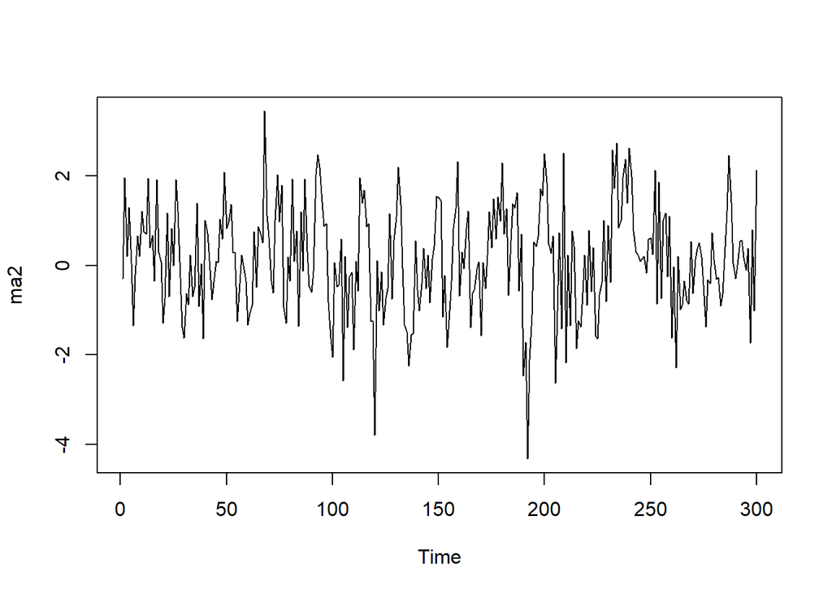

```r
ts.plot(ma2)
```

Berdasarkan plot time series, terlihat bahwa data MA(2) yang dibangkitkan stasioner dalam rataan

### Plot ACF

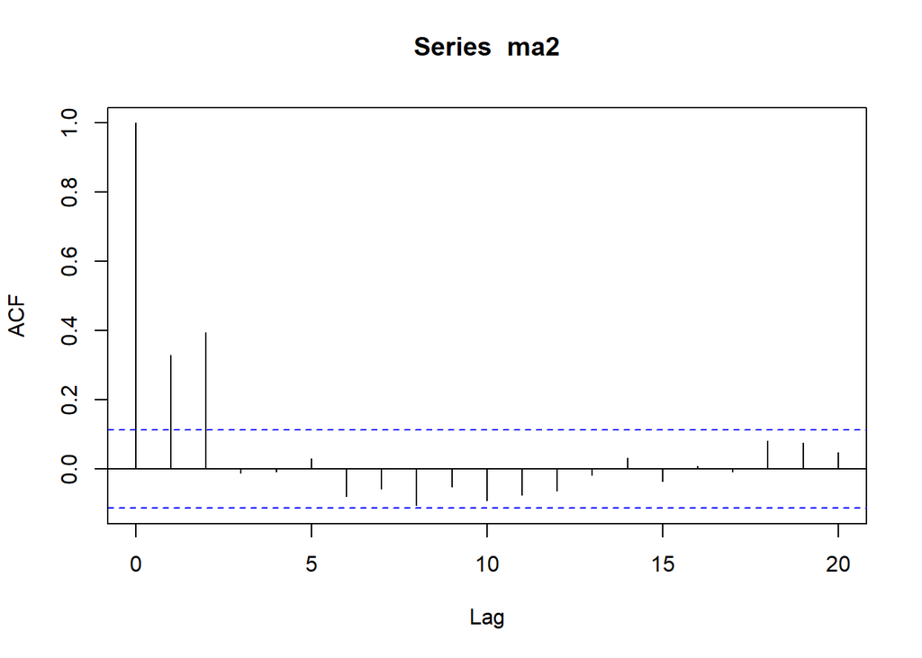

```r
acf(ma2,lag.max = 20)
```

Berdasarkan plot AFC tersebut, terlihat bahwa plot ACF *cuts off* di lag kedua

### Plot PACF

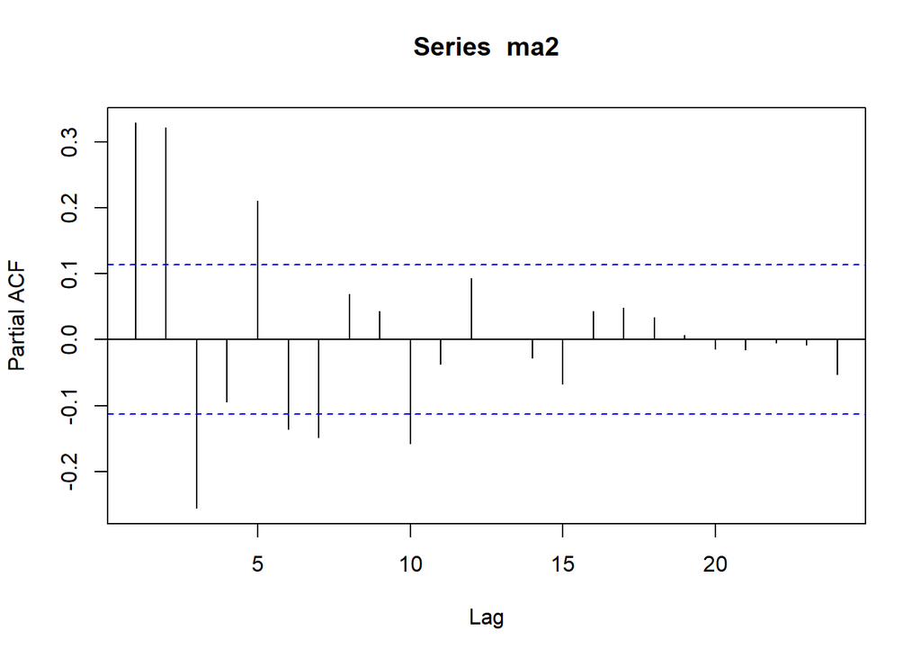

```r
pacf(ma2)
```

Berdasarkan plot PACF tersebut, terlihat bahwa plot PACF cenderung *tails off* dan membentuk gelombang sinus

### Plot EACF

```r
TSA::eacf(ma2)
```

```
## AR/MA
##   0 1 2 3 4 5 6 7 8 9 10 11 12 13
## 0 x x o o o o o o o o o  o  o  o
## 1 x x x o o o o o o o o  o  o  o
## 2 x x o o o o o o o o o  o  o  o
## 3 x x o o o o o o o o o  o  o  o
## 4 x x x o x x o o o o o  o  o  o
## 5 x x x x x x o o o o o  o  o  o
## 6 x x x x o o x x o o o  o  o  o
## 7 x x x x x o o x o o o  o  o  o
```

Berdasarkan pola segitiga nol pada plot EACF, terlihat bahwa segitiga nol berada pada ordo AR(0) dan ordo MA(2)

### Scatterplot Antar Lag

#### Korelasi antara $Y_t$ dengan $Y_{t-1}$

```r
#Yt
yt_ma2 <- ma2[-1]
yt_ma2
```

```
##   [1]  1.9471847822  0.2039450696  1.2931078276  0.0480891236 -1.3443863362
##   [6] -0.2071210815  0.6596565425  0.2030366571  1.2024391609  0.7593035708
##  [11]  0.7033449886  1.9403469147  0.3925484551  0.6674976688 -0.3446283632
##  [16]  1.9084081647  0.3019882409  0.0756044605 -1.2845018549 -0.7347703151
##  [21]  1.1684735578 -0.7022092018  0.8164260215 -0.0005709686  1.9069194491
##  [26]  1.2030284748  0.0707856096 -1.3810693189 -1.6142778433 -0.6245852823
##  [31] -0.8725018478  0.2341620404 -0.6939341378 -0.4827299922  1.3884701207
##  [36] -0.9152117468  0.0387632465 -1.6400317856  1.0005821561  0.7046606538
##  [41]  0.1053001179 -0.7675444479 -0.3746294673  0.0867119079  0.0624423465
##  [46]  1.0284534633  0.5889407161  2.0826487470  0.8222595799  0.9659892717
##  [51]  1.3617771939  0.2808865606  0.2927791590 -1.2425251238 -0.6145897515
##  [56]  0.2305059778 -0.0008796766 -0.3538948232 -1.3370825139 -1.0768203043
##  [61] -0.8889290122  0.7482329302 -0.4956215950  0.8665308492  0.6985899983
##  [66]  0.5059316503  3.4378466046  1.1085522764  0.6293708571 -0.3546625549
##  [71] -0.6117615042  1.0054429401  2.0239920538  0.9722914878  1.7884856065
```

[output cut: 45 more lines]

```r
#Yt-1
yt_1_ma2 <- ma2[-300]
yt_1_ma2
```

```
##   [1] -0.2913725396  1.9471847822  0.2039450696  1.2931078276  0.0480891236
##   [6] -1.3443863362 -0.2071210815  0.6596565425  0.2030366571  1.2024391609
##  [11]  0.7593035708  0.7033449886  1.9403469147  0.3925484551  0.6674976688
##  [16] -0.3446283632  1.9084081647  0.3019882409  0.0756044605 -1.2845018549
##  [21] -0.7347703151  1.1684735578 -0.7022092018  0.8164260215 -0.0005709686
##  [26]  1.9069194491  1.2030284748  0.0707856096 -1.3810693189 -1.6142778433
##  [31] -0.6245852823 -0.8725018478  0.2341620404 -0.6939341378 -0.4827299922
##  [36]  1.3884701207 -0.9152117468  0.0387632465 -1.6400317856  1.0005821561
##  [41]  0.7046606538  0.1053001179 -0.7675444479 -0.3746294673  0.0867119079
##  [46]  0.0624423465  1.0284534633  0.5889407161  2.0826487470  0.8222595799
##  [51]  0.9659892717  1.3617771939  0.2808865606  0.2927791590 -1.2425251238
##  [56] -0.6145897515  0.2305059778 -0.0008796766 -0.3538948232 -1.3370825139
##  [61] -1.0768203043 -0.8889290122  0.7482329302 -0.4956215950  0.8665308492
##  [66]  0.6985899983  0.5059316503  3.4378466046  1.1085522764  0.6293708571
##  [71] -0.3546625549 -0.6117615042  1.0054429401  2.0239920538  0.9722914878
```

[output cut: 45 more lines]

```r
cor(yt_ma2,yt_1_ma2)
```

```
## [1] 0.3298152
```

Korelasi antara $Y_t$ dengan $Y_{t-1}$ hasil simulasi yaitu 0.3298152

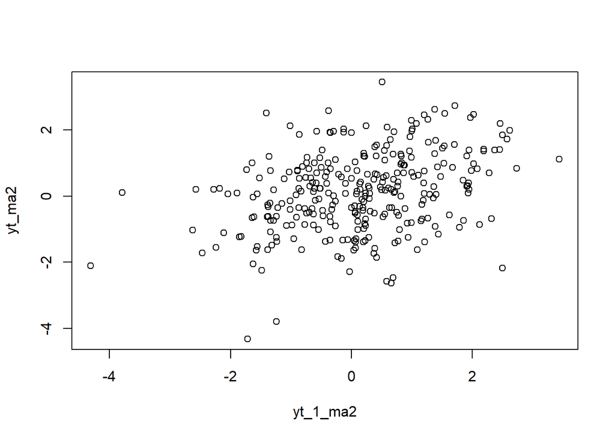

```r
plot(y=yt_ma2,x=yt_1_ma2)
```

Berdasarkan scatterplot tersebut, terlihat bahwa cenderung terdapat hubungan positif lemah antara $Y_t$ dengan $Y_{t-1}$.

#### Korelasi antara $Y_t$ dengan $Y_{t-2}$

```r
#Yt
yt_ma2 <- ma2[-c(1,2)]
yt_ma2
```

```
##   [1]  0.2039450696  1.2931078276  0.0480891236 -1.3443863362 -0.2071210815
##   [6]  0.6596565425  0.2030366571  1.2024391609  0.7593035708  0.7033449886
##  [11]  1.9403469147  0.3925484551  0.6674976688 -0.3446283632  1.9084081647
##  [16]  0.3019882409  0.0756044605 -1.2845018549 -0.7347703151  1.1684735578
##  [21] -0.7022092018  0.8164260215 -0.0005709686  1.9069194491  1.2030284748
##  [26]  0.0707856096 -1.3810693189 -1.6142778433 -0.6245852823 -0.8725018478
##  [31]  0.2341620404 -0.6939341378 -0.4827299922  1.3884701207 -0.9152117468
##  [36]  0.0387632465 -1.6400317856  1.0005821561  0.7046606538  0.1053001179
##  [41] -0.7675444479 -0.3746294673  0.0867119079  0.0624423465  1.0284534633
##  [46]  0.5889407161  2.0826487470  0.8222595799  0.9659892717  1.3617771939
##  [51]  0.2808865606  0.2927791590 -1.2425251238 -0.6145897515  0.2305059778
##  [56] -0.0008796766 -0.3538948232 -1.3370825139 -1.0768203043 -0.8889290122
##  [61]  0.7482329302 -0.4956215950  0.8665308492  0.6985899983  0.5059316503
##  [66]  3.4378466046  1.1085522764  0.6293708571 -0.3546625549 -0.6117615042
##  [71]  1.0054429401  2.0239920538  0.9722914878  1.7884856065 -0.9500941082
```

[output cut: 45 more lines]

```r
#Yt-2
yt_2_ma2 <- ma2[-c(299,300)]
yt_2_ma2
```

```
##   [1] -0.2913725396  1.9471847822  0.2039450696  1.2931078276  0.0480891236
##   [6] -1.3443863362 -0.2071210815  0.6596565425  0.2030366571  1.2024391609
##  [11]  0.7593035708  0.7033449886  1.9403469147  0.3925484551  0.6674976688
##  [16] -0.3446283632  1.9084081647  0.3019882409  0.0756044605 -1.2845018549
##  [21] -0.7347703151  1.1684735578 -0.7022092018  0.8164260215 -0.0005709686
##  [26]  1.9069194491  1.2030284748  0.0707856096 -1.3810693189 -1.6142778433
##  [31] -0.6245852823 -0.8725018478  0.2341620404 -0.6939341378 -0.4827299922
##  [36]  1.3884701207 -0.9152117468  0.0387632465 -1.6400317856  1.0005821561
##  [41]  0.7046606538  0.1053001179 -0.7675444479 -0.3746294673  0.0867119079
##  [46]  0.0624423465  1.0284534633  0.5889407161  2.0826487470  0.8222595799
##  [51]  0.9659892717  1.3617771939  0.2808865606  0.2927791590 -1.2425251238
##  [56] -0.6145897515  0.2305059778 -0.0008796766 -0.3538948232 -1.3370825139
##  [61] -1.0768203043 -0.8889290122  0.7482329302 -0.4956215950  0.8665308492
##  [66]  0.6985899983  0.5059316503  3.4378466046  1.1085522764  0.6293708571
##  [71] -0.3546625549 -0.6117615042  1.0054429401  2.0239920538  0.9722914878
```

[output cut: 45 more lines]

```r
cor(yt_ma2,yt_2_ma2)
```

```
## [1] 0.3985644
```

Korelasi antara $Y_t$ dengan $Y_{t-2}$ hasil simulasi 0.3985644

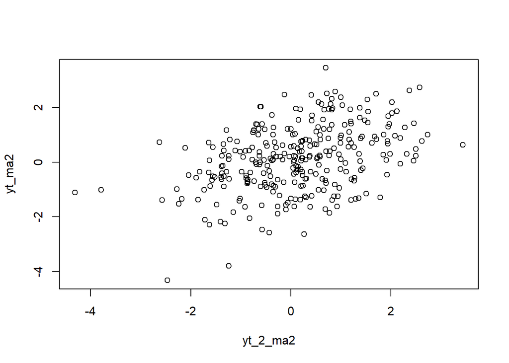

```r
plot(y=yt_ma2,x=yt_2_ma2)
```

Berdasarkan scatterplot tersebut, terlihat bahwa cenderung terdapat hubungan psitif lemah antara $Y_t$ dengan $Y_{t-2}$.

#### Korelasi antara $Y_t$ dengan $Y_{t-3}$

```r
#Yt
yt_ma2 <- ma2[-c(1,2,3)]
yt_ma2
```

```
##   [1]  1.2931078276  0.0480891236 -1.3443863362 -0.2071210815  0.6596565425
##   [6]  0.2030366571  1.2024391609  0.7593035708  0.7033449886  1.9403469147
##  [11]  0.3925484551  0.6674976688 -0.3446283632  1.9084081647  0.3019882409
##  [16]  0.0756044605 -1.2845018549 -0.7347703151  1.1684735578 -0.7022092018
##  [21]  0.8164260215 -0.0005709686  1.9069194491  1.2030284748  0.0707856096
##  [26] -1.3810693189 -1.6142778433 -0.6245852823 -0.8725018478  0.2341620404
##  [31] -0.6939341378 -0.4827299922  1.3884701207 -0.9152117468  0.0387632465
##  [36] -1.6400317856  1.0005821561  0.7046606538  0.1053001179 -0.7675444479
##  [41] -0.3746294673  0.0867119079  0.0624423465  1.0284534633  0.5889407161
##  [46]  2.0826487470  0.8222595799  0.9659892717  1.3617771939  0.2808865606
##  [51]  0.2927791590 -1.2425251238 -0.6145897515  0.2305059778 -0.0008796766
##  [56] -0.3538948232 -1.3370825139 -1.0768203043 -0.8889290122  0.7482329302
##  [61] -0.4956215950  0.8665308492  0.6985899983  0.5059316503  3.4378466046
##  [66]  1.1085522764  0.6293708571 -0.3546625549 -0.6117615042  1.0054429401
##  [71]  2.0239920538  0.9722914878  1.7884856065 -0.9500941082 -1.2890124481
```

[output cut: 45 more lines]

```r
#Yt-2
yt_3_ma2 <- ma2[-c(298,299,300)]
yt_3_ma2
```

```
##   [1] -0.2913725396  1.9471847822  0.2039450696  1.2931078276  0.0480891236
##   [6] -1.3443863362 -0.2071210815  0.6596565425  0.2030366571  1.2024391609
##  [11]  0.7593035708  0.7033449886  1.9403469147  0.3925484551  0.6674976688
##  [16] -0.3446283632  1.9084081647  0.3019882409  0.0756044605 -1.2845018549
##  [21] -0.7347703151  1.1684735578 -0.7022092018  0.8164260215 -0.0005709686
##  [26]  1.9069194491  1.2030284748  0.0707856096 -1.3810693189 -1.6142778433
##  [31] -0.6245852823 -0.8725018478  0.2341620404 -0.6939341378 -0.4827299922
##  [36]  1.3884701207 -0.9152117468  0.0387632465 -1.6400317856  1.0005821561
##  [41]  0.7046606538  0.1053001179 -0.7675444479 -0.3746294673  0.0867119079
##  [46]  0.0624423465  1.0284534633  0.5889407161  2.0826487470  0.8222595799
##  [51]  0.9659892717  1.3617771939  0.2808865606  0.2927791590 -1.2425251238
##  [56] -0.6145897515  0.2305059778 -0.0008796766 -0.3538948232 -1.3370825139
##  [61] -1.0768203043 -0.8889290122  0.7482329302 -0.4956215950  0.8665308492
##  [66]  0.6985899983  0.5059316503  3.4378466046  1.1085522764  0.6293708571
##  [71] -0.3546625549 -0.6117615042  1.0054429401  2.0239920538  0.9722914878
```

[output cut: 45 more lines]

```r
cor(yt_ma2,yt_3_ma2)
```

```
## [1] -0.01106738
```

Korelasi antara $Y_t$ dengan $Y_{t-3}$ hasil simulasi mendekati teori yang ada yaitu -0.01106738

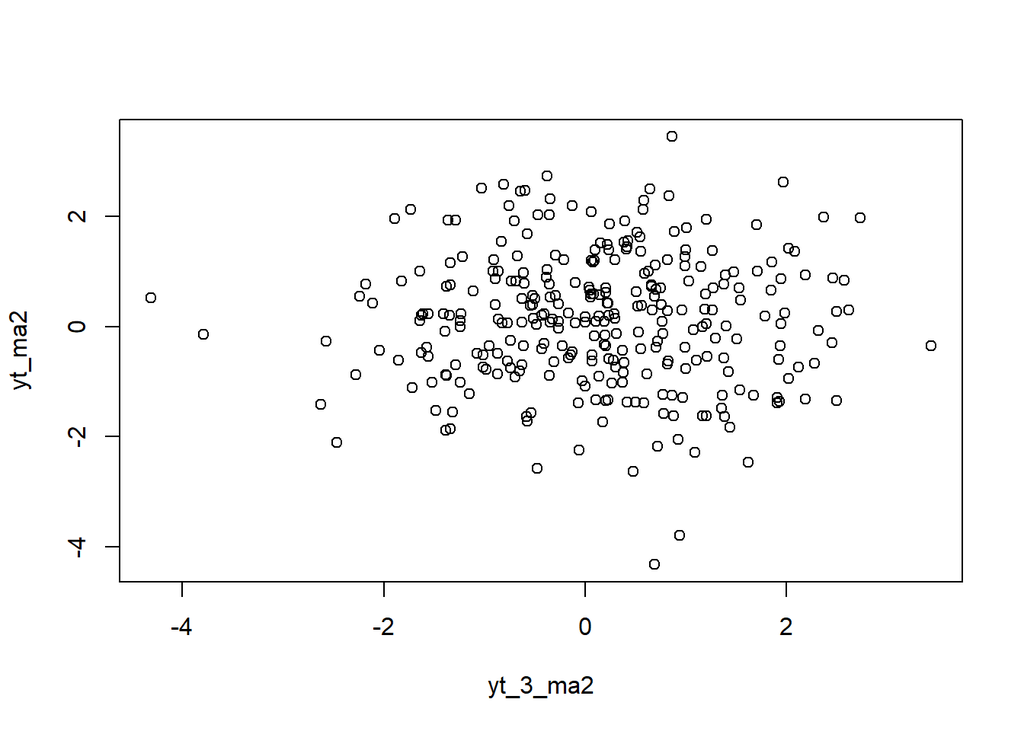

```r
plot(y=yt_ma2,x=yt_3_ma2)
```

Berdasarkan scatterplot tersebut, terlihat bahwa cenderung tidak terdapat hubungan antara $Y_t$ dengan $Y_{t-3}$.

# Proses AR

Proses AR dapat dituliskan sebagai berikut:

$$y_{t} = c + e_t + \phi_{1}Y_{t-1} +
\phi_{2}Y_{t-2} + \dots + \phi_{q}Y_{t-q} = c+{e_t+\sum_{i=1}^p
\phi_iY_{t-i}}$$
Terlihat bahwa $Y_t$ berperan penting dalam pembangkitan proses AR.

## Pembangkitan Proses AR

Akan dicoba membangkitkan proses AR , yaitu AR(2) dengan $\phi_1 = 0.5$ dan $\phi_2 = 0.2$ sebanyak 300 observasi dan $c=0$.

Nilai-nilai selanjutnya dapat dicari melalui *loop*. Bentuk loop dapat dilihat dari rumus AR(2) yang hendak dibangkitkan:

```r
set.seed(1002)
n<-length(wn)
n
```

```
## [1] 300
```

```r
ar <- c(2:n)
for (i in 3:n) {ar[i]<-wn[i]+0.5*ar[i-1]+0.2*ar[i-2]}
ar
```

```
##   [1]  2.0000000000  3.0000000000  1.5777489568  3.2941825568  1.5978135339
##   [6]  1.7535972732  1.3450053906 -0.5581342021  0.3261690081  1.5254340049
##  [11]  0.2396559060  0.9782860694  1.4280061994  0.9246097195  2.1477140618
##  [16]  1.0824346015  0.8689107540  0.4528603017  2.4489628800  0.9163907073
##  [21] -0.0461928397 -0.4874501497 -0.1321727478  1.3451599187 -0.7320328580
##  [26]  0.3654710899  0.6776827513  1.7848402105  1.2970110168  0.1448946455
##  [31] -0.8664208476 -1.0228538455 -0.3428852101 -1.0140721643 -0.2913230970
##  [36] -0.7732908559 -0.9282881060  1.2179080447 -0.9365726180 -0.7440200072
##  [41] -1.1757087785  0.8220666502  0.6268927577 -0.5324756731 -0.7748702931
##  [46] -0.0087541161  0.1136969301 -0.2827849295  0.8811245850  0.7757645000
##  [51]  1.8901856384  1.1570183945  1.1041794437  2.0521537420  0.9317553126
##  [56]  0.5339543378 -0.4631607973 -0.1673712310  0.6211143001 -0.0172205828
##  [61] -0.5990201049 -1.1776015215 -1.0067865409 -0.9837814718  0.3318411004
##  [66] -0.7895722587  0.2265540591  0.8872056975  0.2891248820  3.2806598247
##  [71]  1.7431179347  0.3638828245  0.6144478598  0.4329707110  1.2733000647
```

[output cut: 45 more lines]

Selain menggunakan cara di atas, pembangkitan proses AR dapat dilakukan dengan fungsi `arima.sim()` sebagai berikut.

```r
set.seed(1002)
ar2 <- arima.sim(list(order=c(2,0,0), ar=c(0.5,0.2)), n=300)
ar2
```

```
## Time Series:
## Start = 1
## End = 300
## Frequency = 1
##   [1]  0.3617754456  0.6748653860  1.7826923989  1.2953736379  0.1436463938
##   [6] -0.8673724492 -1.0235792966 -0.3434382560 -1.0144937775 -0.2916445128
##  [11] -0.7735358864 -0.9284749044  1.2177656394 -0.9366811803 -0.7441027694
##  [16] -1.1757718721  0.8220185510  0.6268560893 -0.5325036271 -0.7748916038
##  [21] -0.0087703622  0.1136845449 -0.2827943713  0.8811173871  0.7757590126
##  [26]  1.8901814551  1.1570152054  1.1041770125  2.0521518885  0.9317538996
##  [31]  0.5339532607 -0.4631616185 -0.1673718570  0.6211138228 -0.0172209466
##  [36] -0.5990203823 -1.1776017330 -1.0067867021 -0.9837815947  0.3318410068
##  [41] -0.7895723302  0.2265540046  0.8872056560  0.2891248503  3.2806598006
##  [46]  1.7431179163  0.3638828105  0.6144478491  0.4329707028  1.2733000585
##  [51]  2.3418840390  1.1900824890  1.9749275542  0.0520940912 -0.9455311193
```

[output cut: 49 more lines]

## Karakteristik AR(2)

### Plot Time Series

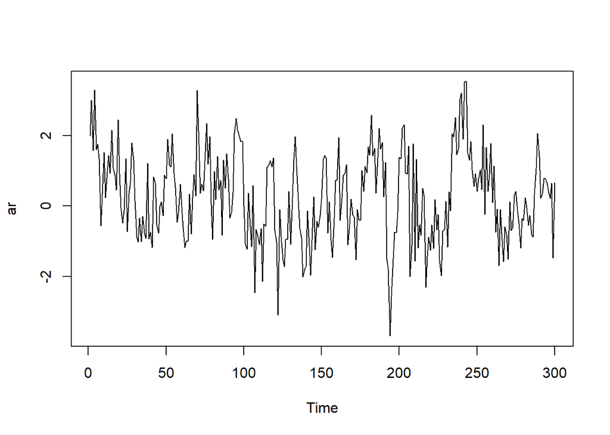

```r
ts.plot(ar)
```

Berdasarkan plot time series tersebut terlihat bahwa data cenderung stasioner pada rataan

### Plot ACF

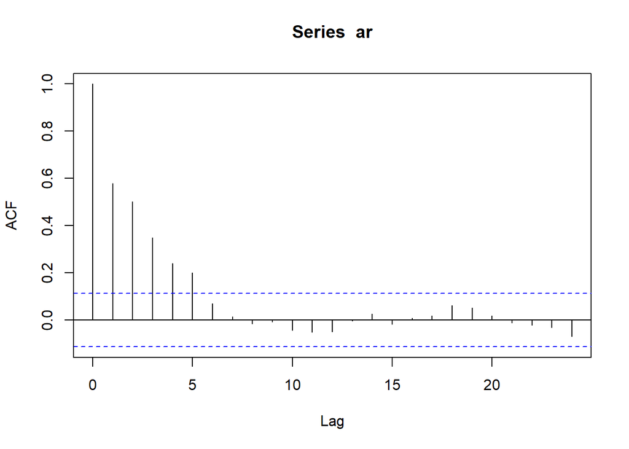

```r
acf(ar)
```

### Plot PACF

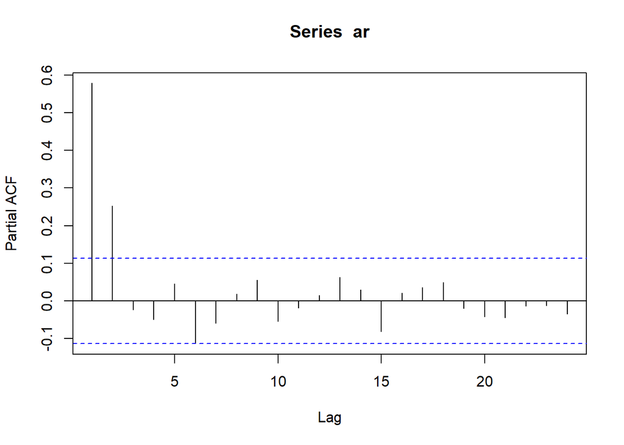

```r
pacf(ar)
```

### Plot EACF

```r
TSA::eacf(ar)
```

```
## AR/MA
##   0 1 2 3 4 5 6 7 8 9 10 11 12 13
## 0 x x x x x o o o o o o  o  o  o
## 1 x x o o x o o o o o o  o  o  o
## 2 o x o o x o o o o o o  o  o  o
## 3 x x o o x o o o o o o  o  o  o
## 4 x x o x x o o o o o o  o  o  o
## 5 x x x x x o o o o o o  o  o  o
## 6 x x x x x o o o o o o  o  o  o
## 7 x x x x x o o o o o o  o  o  o
```

Berdasarkan pola segitiga nol pada plot EACF, tidak terlihat bahwa segitiga nol berada pada ordo AR(2) dan ordo MA(0)

### Scatterplot Antar Lag

#### Korelasi antara $Y_t$ dengan $Y_{t-1}$

```r
#Yt
yt_ar <- ar[-1]
yt_ar
```

```
##   [1]  3.0000000000  1.5777489568  3.2941825568  1.5978135339  1.7535972732
##   [6]  1.3450053906 -0.5581342021  0.3261690081  1.5254340049  0.2396559060
##  [11]  0.9782860694  1.4280061994  0.9246097195  2.1477140618  1.0824346015
##  [16]  0.8689107540  0.4528603017  2.4489628800  0.9163907073 -0.0461928397
##  [21] -0.4874501497 -0.1321727478  1.3451599187 -0.7320328580  0.3654710899
##  [26]  0.6776827513  1.7848402105  1.2970110168  0.1448946455 -0.8664208476
##  [31] -1.0228538455 -0.3428852101 -1.0140721643 -0.2913230970 -0.7732908559
##  [36] -0.9282881060  1.2179080447 -0.9365726180 -0.7440200072 -1.1757087785
##  [41]  0.8220666502  0.6268927577 -0.5324756731 -0.7748702931 -0.0087541161
##  [46]  0.1136969301 -0.2827849295  0.8811245850  0.7757645000  1.8901856384
##  [51]  1.1570183945  1.1041794437  2.0521537420  0.9317553126  0.5339543378
##  [56] -0.4631607973 -0.1673712310  0.6211143001 -0.0172205828 -0.5990201049
##  [61] -1.1776015215 -1.0067865409 -0.9837814718  0.3318411004 -0.7895722587
##  [66]  0.2265540591  0.8872056975  0.2891248820  3.2806598247  1.7431179347
##  [71]  0.3638828245  0.6144478598  0.4329707110  1.2733000647  2.3418840437
```

[output cut: 45 more lines]

```r
#Yt-1
yt_1_ar <- ar[-300]
yt_1_ar
```

```
##   [1]  2.0000000000  3.0000000000  1.5777489568  3.2941825568  1.5978135339
##   [6]  1.7535972732  1.3450053906 -0.5581342021  0.3261690081  1.5254340049
##  [11]  0.2396559060  0.9782860694  1.4280061994  0.9246097195  2.1477140618
##  [16]  1.0824346015  0.8689107540  0.4528603017  2.4489628800  0.9163907073
##  [21] -0.0461928397 -0.4874501497 -0.1321727478  1.3451599187 -0.7320328580
##  [26]  0.3654710899  0.6776827513  1.7848402105  1.2970110168  0.1448946455
##  [31] -0.8664208476 -1.0228538455 -0.3428852101 -1.0140721643 -0.2913230970
##  [36] -0.7732908559 -0.9282881060  1.2179080447 -0.9365726180 -0.7440200072
##  [41] -1.1757087785  0.8220666502  0.6268927577 -0.5324756731 -0.7748702931
##  [46] -0.0087541161  0.1136969301 -0.2827849295  0.8811245850  0.7757645000
##  [51]  1.8901856384  1.1570183945  1.1041794437  2.0521537420  0.9317553126
##  [56]  0.5339543378 -0.4631607973 -0.1673712310  0.6211143001 -0.0172205828
##  [61] -0.5990201049 -1.1776015215 -1.0067865409 -0.9837814718  0.3318411004
##  [66] -0.7895722587  0.2265540591  0.8872056975  0.2891248820  3.2806598247
##  [71]  1.7431179347  0.3638828245  0.6144478598  0.4329707110  1.2733000647
```

[output cut: 45 more lines]

```r
cor(yt_ar,yt_1_ar)
```

```
## [1] 0.5799812
```

Korelasi antara $Y_t$ dengan $Y_{t-1}$ dari hasil simulasi sebesar 0.5799812

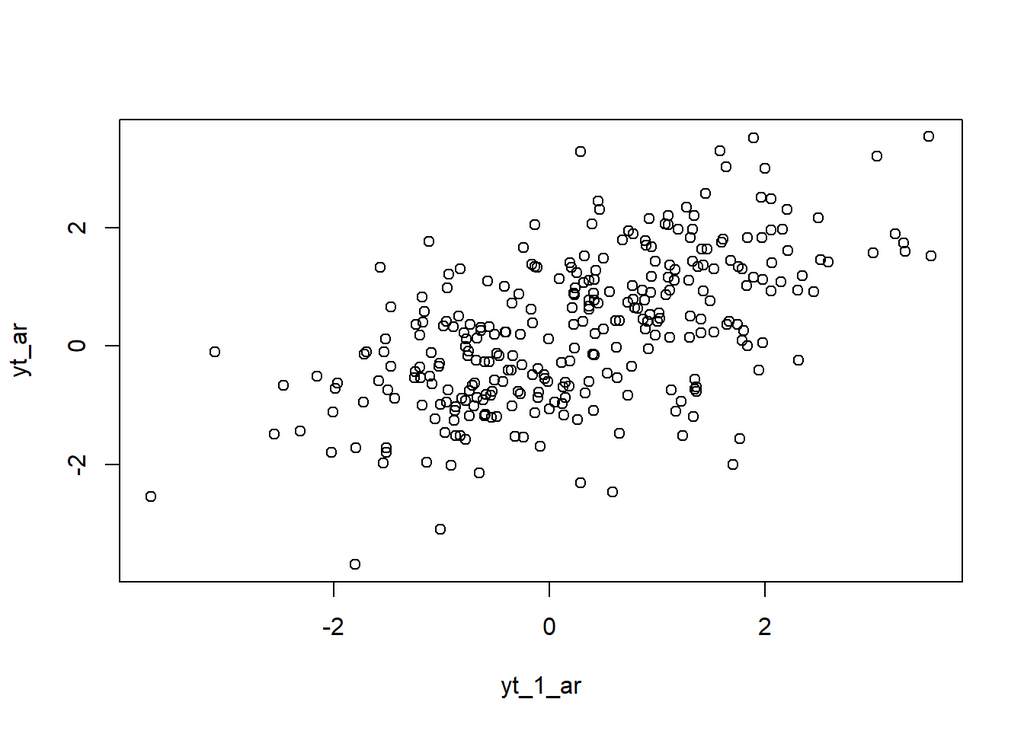

```r
plot(y=yt_ar,x=yt_1_ar)
```

Berdasarkan scatterplot tersebut, terlihat bahwa cenderung terdapat hubungan positif antara $Y_t$ dengan $Y_{t-1}$.

#### Korelasi antara $Y_t$ dengan $Y_{t-2}$

```r
#Yt
yt2_ar <- ar[-c(1,2)]
yt2_ar
```

```
##   [1]  1.5777489568  3.2941825568  1.5978135339  1.7535972732  1.3450053906
##   [6] -0.5581342021  0.3261690081  1.5254340049  0.2396559060  0.9782860694
##  [11]  1.4280061994  0.9246097195  2.1477140618  1.0824346015  0.8689107540
##  [16]  0.4528603017  2.4489628800  0.9163907073 -0.0461928397 -0.4874501497
##  [21] -0.1321727478  1.3451599187 -0.7320328580  0.3654710899  0.6776827513
##  [26]  1.7848402105  1.2970110168  0.1448946455 -0.8664208476 -1.0228538455
##  [31] -0.3428852101 -1.0140721643 -0.2913230970 -0.7732908559 -0.9282881060
##  [36]  1.2179080447 -0.9365726180 -0.7440200072 -1.1757087785  0.8220666502
##  [41]  0.6268927577 -0.5324756731 -0.7748702931 -0.0087541161  0.1136969301
##  [46] -0.2827849295  0.8811245850  0.7757645000  1.8901856384  1.1570183945
##  [51]  1.1041794437  2.0521537420  0.9317553126  0.5339543378 -0.4631607973
##  [56] -0.1673712310  0.6211143001 -0.0172205828 -0.5990201049 -1.1776015215
##  [61] -1.0067865409 -0.9837814718  0.3318411004 -0.7895722587  0.2265540591
##  [66]  0.8872056975  0.2891248820  3.2806598247  1.7431179347  0.3638828245
##  [71]  0.6144478598  0.4329707110  1.2733000647  2.3418840437  1.1900824926
```

[output cut: 45 more lines]

```r
#Yt-2
yt_2_ar <- ar[-c(299,300)]
yt_2_ar
```

```
##   [1]  2.0000000000  3.0000000000  1.5777489568  3.2941825568  1.5978135339
##   [6]  1.7535972732  1.3450053906 -0.5581342021  0.3261690081  1.5254340049
##  [11]  0.2396559060  0.9782860694  1.4280061994  0.9246097195  2.1477140618
##  [16]  1.0824346015  0.8689107540  0.4528603017  2.4489628800  0.9163907073
##  [21] -0.0461928397 -0.4874501497 -0.1321727478  1.3451599187 -0.7320328580
##  [26]  0.3654710899  0.6776827513  1.7848402105  1.2970110168  0.1448946455
##  [31] -0.8664208476 -1.0228538455 -0.3428852101 -1.0140721643 -0.2913230970
##  [36] -0.7732908559 -0.9282881060  1.2179080447 -0.9365726180 -0.7440200072
##  [41] -1.1757087785  0.8220666502  0.6268927577 -0.5324756731 -0.7748702931
##  [46] -0.0087541161  0.1136969301 -0.2827849295  0.8811245850  0.7757645000
##  [51]  1.8901856384  1.1570183945  1.1041794437  2.0521537420  0.9317553126
##  [56]  0.5339543378 -0.4631607973 -0.1673712310  0.6211143001 -0.0172205828
##  [61] -0.5990201049 -1.1776015215 -1.0067865409 -0.9837814718  0.3318411004
##  [66] -0.7895722587  0.2265540591  0.8872056975  0.2891248820  3.2806598247
##  [71]  1.7431179347  0.3638828245  0.6144478598  0.4329707110  1.2733000647
```

[output cut: 45 more lines]

```r
cor(yt2_ar,yt_2_ar)
```

```
## [1] 0.5100164
```

Korelasi antara $Y_t$ dengan $Y_{t-2}$ dari hasil simulasi sebesar 0.5100164.

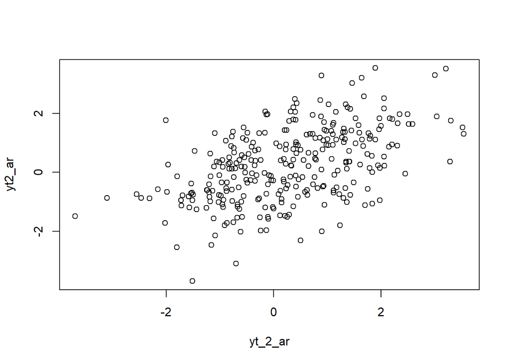

```r
plot(y=yt2_ar,x=yt_2_ar)
```

Berdasarkan scatterplot tersebut, terlihat bahwa cenderung terdapat hubungan positif antara $Y_t$ dengan $Y_{t-2}$.

#### Korelasi antara $Y_t$ dengan $Y_{t-3}$

```r
#Yt
yt3_ar <- ar[-c(1,2,3)]
yt3_ar
```

```
##   [1]  3.2941825568  1.5978135339  1.7535972732  1.3450053906 -0.5581342021
##   [6]  0.3261690081  1.5254340049  0.2396559060  0.9782860694  1.4280061994
##  [11]  0.9246097195  2.1477140618  1.0824346015  0.8689107540  0.4528603017
##  [16]  2.4489628800  0.9163907073 -0.0461928397 -0.4874501497 -0.1321727478
##  [21]  1.3451599187 -0.7320328580  0.3654710899  0.6776827513  1.7848402105
##  [26]  1.2970110168  0.1448946455 -0.8664208476 -1.0228538455 -0.3428852101
##  [31] -1.0140721643 -0.2913230970 -0.7732908559 -0.9282881060  1.2179080447
##  [36] -0.9365726180 -0.7440200072 -1.1757087785  0.8220666502  0.6268927577
##  [41] -0.5324756731 -0.7748702931 -0.0087541161  0.1136969301 -0.2827849295
##  [46]  0.8811245850  0.7757645000  1.8901856384  1.1570183945  1.1041794437
##  [51]  2.0521537420  0.9317553126  0.5339543378 -0.4631607973 -0.1673712310
##  [56]  0.6211143001 -0.0172205828 -0.5990201049 -1.1776015215 -1.0067865409
##  [61] -0.9837814718  0.3318411004 -0.7895722587  0.2265540591  0.8872056975
##  [66]  0.2891248820  3.2806598247  1.7431179347  0.3638828245  0.6144478598
##  [71]  0.4329707110  1.2733000647  2.3418840437  1.1900824926  1.9749275569
```

[output cut: 45 more lines]

```r
#Yt-2
yt_3_ar <- ar[-c(298,299,300)]
yt_3_ar
```

```
##   [1]  2.0000000000  3.0000000000  1.5777489568  3.2941825568  1.5978135339
##   [6]  1.7535972732  1.3450053906 -0.5581342021  0.3261690081  1.5254340049
##  [11]  0.2396559060  0.9782860694  1.4280061994  0.9246097195  2.1477140618
##  [16]  1.0824346015  0.8689107540  0.4528603017  2.4489628800  0.9163907073
##  [21] -0.0461928397 -0.4874501497 -0.1321727478  1.3451599187 -0.7320328580
##  [26]  0.3654710899  0.6776827513  1.7848402105  1.2970110168  0.1448946455
##  [31] -0.8664208476 -1.0228538455 -0.3428852101 -1.0140721643 -0.2913230970
##  [36] -0.7732908559 -0.9282881060  1.2179080447 -0.9365726180 -0.7440200072
##  [41] -1.1757087785  0.8220666502  0.6268927577 -0.5324756731 -0.7748702931
##  [46] -0.0087541161  0.1136969301 -0.2827849295  0.8811245850  0.7757645000
##  [51]  1.8901856384  1.1570183945  1.1041794437  2.0521537420  0.9317553126
##  [56]  0.5339543378 -0.4631607973 -0.1673712310  0.6211143001 -0.0172205828
##  [61] -0.5990201049 -1.1776015215 -1.0067865409 -0.9837814718  0.3318411004
##  [66] -0.7895722587  0.2265540591  0.8872056975  0.2891248820  3.2806598247
##  [71]  1.7431179347  0.3638828245  0.6144478598  0.4329707110  1.2733000647
```

[output cut: 45 more lines]

```r
cor(yt3_ar,yt_3_ar)
```

```
## [1] 0.3544178
```

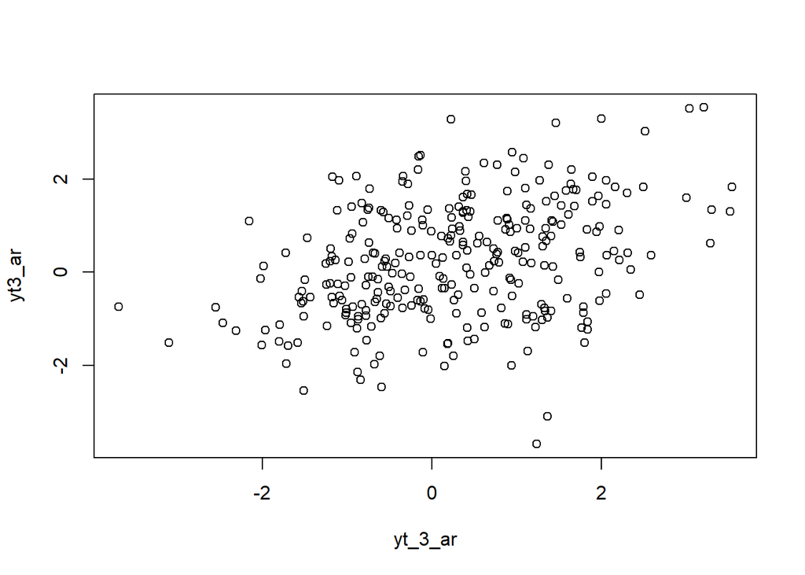

```r
plot(y=yt3_ar,x=yt_3_ar)
```

Berdasarkan scatterplot tersebut, terlihat bahwa terdapat hubungan positif lemah antara $Y_t$ dengan $Y_{t-3}$.

# Fungsi pembangkitan ARMA

Setelah mengetahui cara membangkitkan data berpola AR, MA, bagaimana cara melakukan pembangkitan data berpola tersebut yang lebih kompleks? Apakah dapat dibuat suatu fungsi yang fleksibel yang memungkinan pembangkitan dengan berapapun jumlah koefisien?

Pertama, lihat kembali bentuk umum data berpola ARMA.

$$y_{t} = c + \sum_{i=1}^p \phi_{i}y_{t-i} + \sum_{j=1}^q e_{t-j}+ e_{t}$$

Jika koefisien dan *white noise*/nilai deret waktu sebelumnya dapat diekstrak dalam bentuk vektor, dapat dilakukan perkalian matriks untuk mencari nilai bagian AR dan MA:

```r
set.seed(1002)
coefs <- c(0.5, 0.2)
e <- c(1, 2)

coefs %*% e
```

```
##      [,1]
## [1,]  0.9
```

Atau, dapat dilakukan perkalian *elementwise* yang dijumlahkan:

```r
coefs * e
```

```
## [1] 0.5 0.4
```

```r
sum(coefs * e)
```

```
## [1] 0.9
```

Dari prinsip ini, dapat dibuat fungsi umum untuk membangkitkan data ARMA. Input dari fungsi adalah jumlah data yang hendak dibangkitkan, koefisien MA, dan koefisien AR

```r
arma.sim <- function(n, macoef, arcoef){
  manum <- length(macoef)
  arnum <- length(arcoef)
  stopifnot(manum < n & arnum < n)

  wn <- rnorm(n, sd = 0.5)
  init <- max(manum, arnum)

  arma <- wn[1:init]
  for(i in {init+1}:n){
   mastart <- i - manum
   maend <- i-1
   arstart <- i - arnum
   arend <- i-1
   arma[i] <- sum(arcoef * arma[arstart:arend]) + sum(macoef * wn[mastart:maend])  + wn[i]
   }
  return(arma)
}
```

Terlihat bahwa komponen $\sum_{i=1}^q y_{t-1}$ disimulasikan melalui `sum(arcoef * arma[arstart:arend])`. Jadi, koefisien dikalikan dengan data $y$ dari $t-q$ di mana q adalah jumlah koefisien AR, sampai data $t-1$. Lalu komponen $\sum_{j=1}^q e_{t-j}$ disimulasikan melalui `sum(macoef * wn[mastart:maend])`. Koefisien dikalikan dengan *white noise* $e$ dari $t-p$, p jumlah koefisien MA, sampai $t-1$.

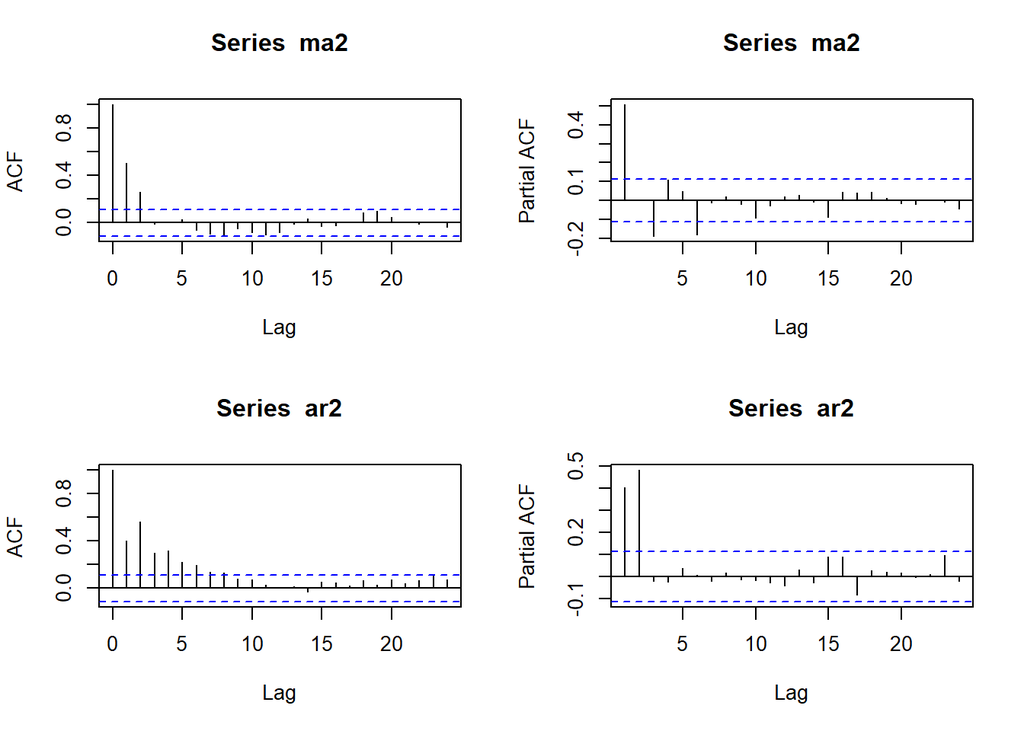

```r
# beberapa contoh pembangkitan melalui fungsi

ma2 <- arma.sim(300, c(0.4, 0.6), 0)
ar2 <- arma.sim(300, 0, c(0.5, 0.2))

par(mfrow = c(2, 2))
acf(ma2)
pacf(ma2)
acf(ar2)
pacf(ar2)
```

```r
#contoh untuk ARMA
arma22 <- arma.sim(300, c(0.5, 0.2), c(0.4,0.6))

arma22 |> arima(c(2,0,2))
```

```
##
## Call:
## arima(x = arma22, order = c(2, 0, 2))
##
## Coefficients:
##          ar1     ar2     ma1     ma2  intercept
##       0.4759  0.4968  0.2355  0.4966    -1.2354
## s.e.  0.0781  0.0781  0.0710  0.0594     1.4949
##
## sigma^2 estimated as 0.221:  log likelihood = -201.48,  aic = 414.96
```

```r
set.seed(1002)
n = length(wn)
phi1 = 0.5
theta1 = 0.4
phi2=0.2
theta2=0.6

y.arma=c(1:n)
for (i in 3:n){y.arma[i] = phi1*y.arma[i-1] + theta1*wn[i-1] + phi2*y.arma[i-2] + theta2*wn[i-2]+wn[i]}
y.arma
```

```
##   [1]  1.00000000  2.00000000  0.90862746  2.80149851  1.78641982  2.74661744
##   [7]  1.77868181  0.09427805  0.19575431  0.77638931  0.63038217  1.67290811
##  [13]  1.72183406  1.89884364  3.23413555  2.38938496  2.50901726  1.38775726
##  [19]  3.10409024  2.13158481  1.76221492  0.02292257 -0.37086605  0.98762505
##  [25] -0.28256989  0.87266609  0.37924810  2.27107672  2.41441645  1.73220918
##  [31] -0.03208144 -1.28387673 -1.27293993 -1.76574716 -0.90329953 -1.49873333
##  [37] -1.41275656  0.38234517 -1.00659047 -0.38806296 -2.03538136 -0.09472111
##  [43]  0.25022383  0.21146781 -0.61176578 -0.63821880 -0.35475065 -0.24257674
##  [49]  0.83621497  0.95853285  2.72915817  2.37854523  2.70109352  3.18803300
##  [55]  2.41512177  2.13794664  0.30947255 -0.03226415  0.27626841  0.13080170
##  [61] -0.23324029 -1.42754232 -1.83723952 -2.09305724 -0.66574359 -1.24710484
##  [67]  0.10982971  0.50408389  0.77993954  3.92863315  3.22885676  3.02952587
##  [73]  1.80587173  0.89707953  1.81515705  3.11098649  2.89081614  3.85609097
##  [79]  1.55611461  0.26026305  0.63341166  0.01252691  2.06466262  1.12791947
##  [85]  1.74915584 -0.26441943  1.41014043  0.52553214  2.47027528  1.65508279
```

[output cut: 35 more lines]

Pembangkitan ARMA(p,q) juga dapat dilakukan dengan fungsi `arima.sim` sebagai berikut.

```r
set.seed(1002)
arma22 <- arima.sim(list(order=c(2,0,2), ar = c(0.5,0.2), ma = c(0.4,0.6)), n=300)
arma22
```

```
## Time Series:
## Start = 1
## End = 300
## Frequency = 1
##   [1]  2.26962428  2.41330919  1.73136506 -0.03272495 -1.28436730 -1.27331392
##   [7] -1.76603227 -0.90351688 -1.49889903 -1.41288288  0.38224887 -1.00666389
##  [13] -0.38811892 -2.03542402 -0.09475364  0.25019903  0.21144890 -0.61178019
##  [19] -0.63822978 -0.35475902 -0.24258312  0.83621010  0.95852914  2.72915534
##  [25]  2.37854308  2.70109188  3.18803175  2.41512081  2.13794591  0.30947200
##  [31] -0.03226457  0.27626809  0.13080145 -0.23324048 -1.42754246 -1.83723963
##  [37] -2.09305732 -0.66574366 -1.24710489  0.10982967  0.50408386  0.77993951
##  [43]  3.92863313  3.22885675  3.02952586  1.80587172  0.89707953  1.81515705
##  [49]  3.11098648  2.89081614  3.85609097  1.55611461  0.26026305  0.63341166
##  [55]  0.01252691  2.06466262  1.12791947  1.74915584 -0.26441943  1.41014043
##  [61]  0.52553214  2.47027528  1.65508279  0.85592497  0.16129761  0.12655585
```

[output cut: 39 more lines]

# Karakteristik ARMA(2,2)

## Plot Time Series

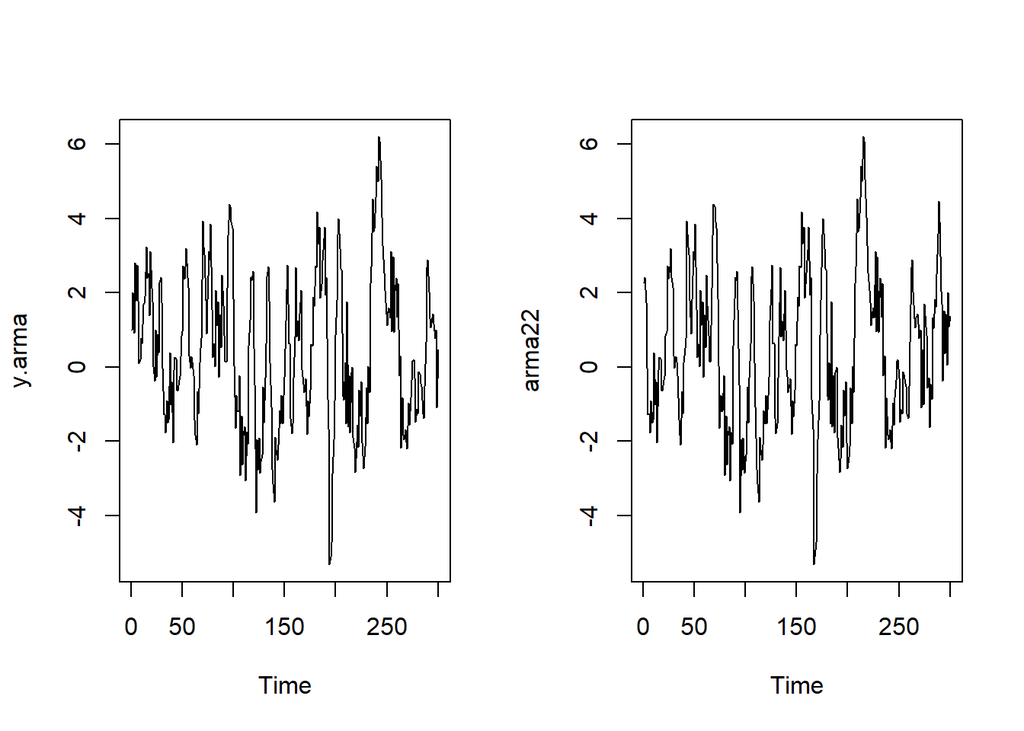

```r
par(mfrow = c(1, 2))
ts.plot(y.arma)
ts.plot(arma22)
```

```r
par(mfrow = c(1, 1))
```

Berdasarkan plot time series tersebut, terlihat bahwa model ARMA(2,2) cenderung stasioner dalam rataan

## Plot ACF

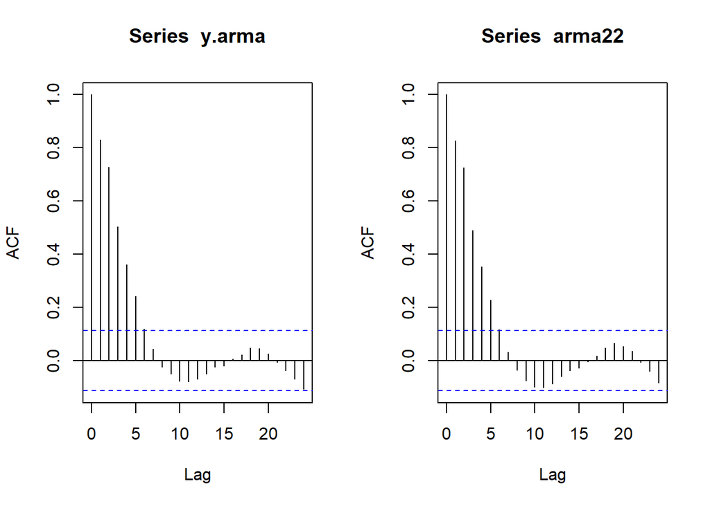

```r
par(mfrow = c(1, 2))
acf(y.arma)
acf(arma22)
```

```r
par(mfrow = c(2, 2))
```

Berdasarkan plot ACF tersebut, terlihat bahwa model ARMA(2,2) hasil simulasi memiliki plot ACF yang *tails off*, sesuai dengan teori yang ada

## Plot PACF

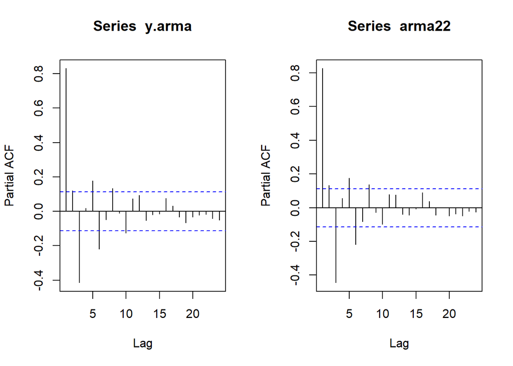

```r
par(mfrow = c(1, 2))
pacf(y.arma)
pacf(arma22)
```

```r
par(mfrow = c(2, 2))
```

## Plot EACF

```r
TSA::eacf(y.arma)
```

```
## AR/MA
##   0 1 2 3 4 5 6 7 8 9 10 11 12 13
## 0 x x x x x x o o o o o  o  o  o
## 1 x x o o x o o o o o o  o  o  o
## 2 x x x o x o o o o o o  o  o  o
## 3 o x x x x o o o o o o  o  o  o
## 4 x x x o x x o o o o o  o  o  o
## 5 x x x x x x o o o o o  o  o  o
## 6 x x o x o o o o o o o  o  o  o
## 7 x x o x o o o x o o o  o  o  o
```

```r
TSA::eacf(arma22)
```

```
## AR/MA
##   0 1 2 3 4 5 6 7 8 9 10 11 12 13
## 0 x x x x x o o o o o o  o  o  o
## 1 x x o o x o o o o o o  o  o  o
## 2 x x x o o o o o o o o  o  o  o
## 3 o x x x x o o o o o o  o  o  o
## 4 x x x o x o o o o o o  o  o  o
## 5 x x x o x o o o o o o  o  o  o
## 6 x x x x x o o o o o o  o  o  o
## 7 x x x o x x o o o o o  o  o  o
```

Berdasarkan pola segitiga nol pada plot EACF, tidak terlihat bahwa segitiga nol berada pada ordo AR(2) dan ordo MA(2)

## Scatterplot Antar Lag

### Korelasi antara $Y_t$ dengan $Y_{t-1}$

```r
#Yt
yt1_arma <- arma22[-1]
yt1_arma
```

```
##   [1]  2.41330919  1.73136506 -0.03272495 -1.28436730 -1.27331392 -1.76603227
##   [7] -0.90351688 -1.49889903 -1.41288288  0.38224887 -1.00666389 -0.38811892
##  [13] -2.03542402 -0.09475364  0.25019903  0.21144890 -0.61178019 -0.63822978
##  [19] -0.35475902 -0.24258312  0.83621010  0.95852914  2.72915534  2.37854308
##  [25]  2.70109188  3.18803175  2.41512081  2.13794591  0.30947200 -0.03226457
##  [31]  0.27626809  0.13080145 -0.23324048 -1.42754246 -1.83723963 -2.09305732
##  [37] -0.66574366 -1.24710489  0.10982967  0.50408386  0.77993951  3.92863313
##  [43]  3.22885675  3.02952586  1.80587172  0.89707953  1.81515705  3.11098648
##  [49]  2.89081614  3.85609097  1.55611461  0.26026305  0.63341166  0.01252691
##  [55]  2.06466262  1.12791947  1.74915584 -0.26441943  1.41014043  0.52553214
##  [61]  2.47027528  1.65508279  0.85592497  0.16129761  0.12655585  2.11865682
##  [67]  3.54717417  4.38837807  4.32503517  3.91681579  3.75017384  1.83524505
##  [73]  0.04118502 -1.65611843 -0.76047493 -1.18806381 -1.17354412 -0.23786915
##  [79] -2.92601625 -1.30875347 -2.62607044 -1.84193357 -1.60843881 -3.06122751
##  [85] -1.75594837 -2.06753876  0.56382000  1.25962463  2.41656249  2.32738027
```

[output cut: 35 more lines]

```r
#Yt-1
yt_1_arma <- arma22[-300]
yt_1_arma
```

```
##   [1]  2.26962428  2.41330919  1.73136506 -0.03272495 -1.28436730 -1.27331392
##   [7] -1.76603227 -0.90351688 -1.49889903 -1.41288288  0.38224887 -1.00666389
##  [13] -0.38811892 -2.03542402 -0.09475364  0.25019903  0.21144890 -0.61178019
##  [19] -0.63822978 -0.35475902 -0.24258312  0.83621010  0.95852914  2.72915534
##  [25]  2.37854308  2.70109188  3.18803175  2.41512081  2.13794591  0.30947200
##  [31] -0.03226457  0.27626809  0.13080145 -0.23324048 -1.42754246 -1.83723963
##  [37] -2.09305732 -0.66574366 -1.24710489  0.10982967  0.50408386  0.77993951
##  [43]  3.92863313  3.22885675  3.02952586  1.80587172  0.89707953  1.81515705
##  [49]  3.11098648  2.89081614  3.85609097  1.55611461  0.26026305  0.63341166
##  [55]  0.01252691  2.06466262  1.12791947  1.74915584 -0.26441943  1.41014043
##  [61]  0.52553214  2.47027528  1.65508279  0.85592497  0.16129761  0.12655585
##  [67]  2.11865682  3.54717417  4.38837807  4.32503517  3.91681579  3.75017384
##  [73]  1.83524505  0.04118502 -1.65611843 -0.76047493 -1.18806381 -1.17354412
##  [79] -0.23786915 -2.92601625 -1.30875347 -2.62607044 -1.84193357 -1.60843881
##  [85] -3.06122751 -1.75594837 -2.06753876  0.56382000  1.25962463  2.41656249
```

[output cut: 35 more lines]

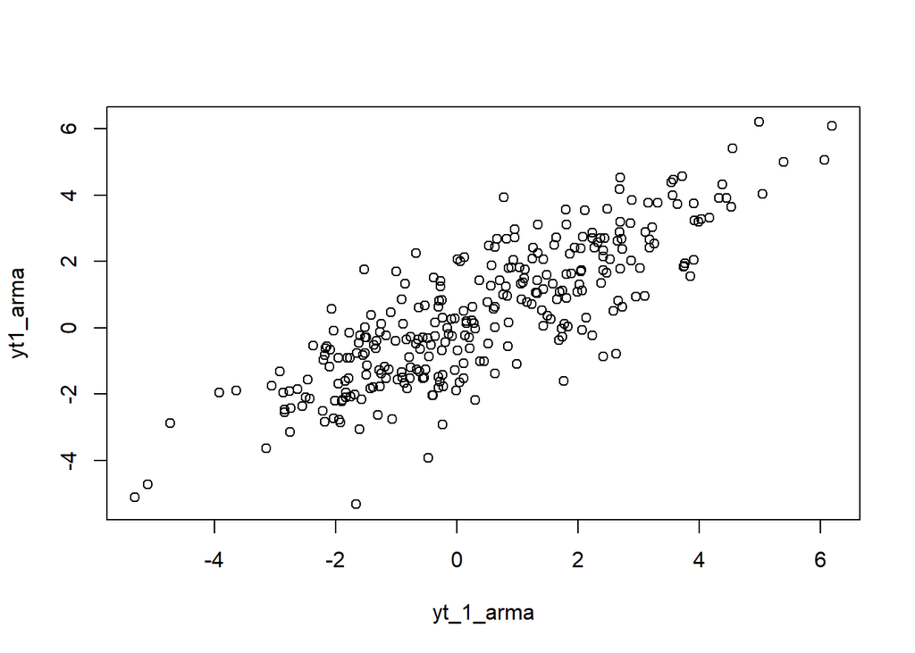

```r
plot(y=yt1_arma,x=yt_1_arma)
```

Berdasarkan scatterplot tersebut, terlihat bahwa terdapat hubungan positif antara $Y_t$ dengan $Y_{t-1}$. Hal ini sesuai dengan teori yang ada

```r
cor(yt1_arma,yt_1_arma)
```

```
## [1] 0.8277724
```

Korelasi antara $Y_t$ dengan $Y_{t-1}$ dari hasil simulasi sebesar 0.8277724

### Korelasi antara $Y_t$ dengan $Y_{t-2}$

```r
#Yt
yt2_arma <- arma22[-c(1,2)]
yt2_arma
```

```
##   [1]  1.73136506 -0.03272495 -1.28436730 -1.27331392 -1.76603227 -0.90351688
##   [7] -1.49889903 -1.41288288  0.38224887 -1.00666389 -0.38811892 -2.03542402
##  [13] -0.09475364  0.25019903  0.21144890 -0.61178019 -0.63822978 -0.35475902
##  [19] -0.24258312  0.83621010  0.95852914  2.72915534  2.37854308  2.70109188
##  [25]  3.18803175  2.41512081  2.13794591  0.30947200 -0.03226457  0.27626809
##  [31]  0.13080145 -0.23324048 -1.42754246 -1.83723963 -2.09305732 -0.66574366
##  [37] -1.24710489  0.10982967  0.50408386  0.77993951  3.92863313  3.22885675
##  [43]  3.02952586  1.80587172  0.89707953  1.81515705  3.11098648  2.89081614
##  [49]  3.85609097  1.55611461  0.26026305  0.63341166  0.01252691  2.06466262
##  [55]  1.12791947  1.74915584 -0.26441943  1.41014043  0.52553214  2.47027528
##  [61]  1.65508279  0.85592497  0.16129761  0.12655585  2.11865682  3.54717417
##  [67]  4.38837807  4.32503517  3.91681579  3.75017384  1.83524505  0.04118502
##  [73] -1.65611843 -0.76047493 -1.18806381 -1.17354412 -0.23786915 -2.92601625
##  [79] -1.30875347 -2.62607044 -1.84193357 -1.60843881 -3.06122751 -1.75594837
##  [85] -2.06753876  0.56382000  1.25962463  2.41656249  2.32738027  2.58492429
```

[output cut: 35 more lines]

```r
#Yt-1
yt_2_arma <- arma22[-c(299,300)]
yt_2_arma
```

```
##   [1]  2.26962428  2.41330919  1.73136506 -0.03272495 -1.28436730 -1.27331392
##   [7] -1.76603227 -0.90351688 -1.49889903 -1.41288288  0.38224887 -1.00666389
##  [13] -0.38811892 -2.03542402 -0.09475364  0.25019903  0.21144890 -0.61178019
##  [19] -0.63822978 -0.35475902 -0.24258312  0.83621010  0.95852914  2.72915534
##  [25]  2.37854308  2.70109188  3.18803175  2.41512081  2.13794591  0.30947200
##  [31] -0.03226457  0.27626809  0.13080145 -0.23324048 -1.42754246 -1.83723963
##  [37] -2.09305732 -0.66574366 -1.24710489  0.10982967  0.50408386  0.77993951
##  [43]  3.92863313  3.22885675  3.02952586  1.80587172  0.89707953  1.81515705
##  [49]  3.11098648  2.89081614  3.85609097  1.55611461  0.26026305  0.63341166
##  [55]  0.01252691  2.06466262  1.12791947  1.74915584 -0.26441943  1.41014043
##  [61]  0.52553214  2.47027528  1.65508279  0.85592497  0.16129761  0.12655585
##  [67]  2.11865682  3.54717417  4.38837807  4.32503517  3.91681579  3.75017384
##  [73]  1.83524505  0.04118502 -1.65611843 -0.76047493 -1.18806381 -1.17354412
##  [79] -0.23786915 -2.92601625 -1.30875347 -2.62607044 -1.84193357 -1.60843881
##  [85] -3.06122751 -1.75594837 -2.06753876  0.56382000  1.25962463  2.41656249
```

[output cut: 35 more lines]

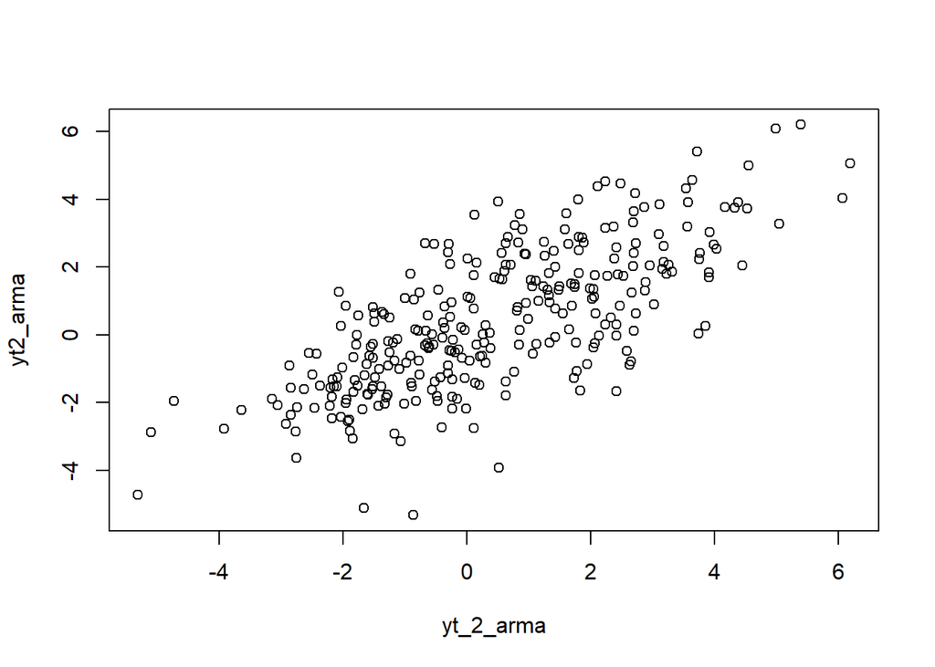

```r
plot(y=yt2_arma,x=yt_2_arma)
```

Berdasarkan scatterplot tersebut, terlihat bahwa terdapat hubungan positif antara $Y_t$ dengan $Y_{t-2}$. Hal ini sesuai dengan teori yang ada

```r
cor(yt2_arma,yt_2_arma)
```

```
## [1] 0.7273334
```

Korelasi antara $Y_t$ dengan $Y_{t-2}$ dari hasil simulasi sebesar 0.7273334

### Korelasi antara $Y_t$ dengan $Y_{t-3}$

```r
#Yt
yt3_arma <- arma22[-c(1,2,3)]
yt3_arma
```

```
##   [1] -0.03272495 -1.28436730 -1.27331392 -1.76603227 -0.90351688 -1.49889903
##   [7] -1.41288288  0.38224887 -1.00666389 -0.38811892 -2.03542402 -0.09475364
##  [13]  0.25019903  0.21144890 -0.61178019 -0.63822978 -0.35475902 -0.24258312
##  [19]  0.83621010  0.95852914  2.72915534  2.37854308  2.70109188  3.18803175
##  [25]  2.41512081  2.13794591  0.30947200 -0.03226457  0.27626809  0.13080145
##  [31] -0.23324048 -1.42754246 -1.83723963 -2.09305732 -0.66574366 -1.24710489
##  [37]  0.10982967  0.50408386  0.77993951  3.92863313  3.22885675  3.02952586
##  [43]  1.80587172  0.89707953  1.81515705  3.11098648  2.89081614  3.85609097
##  [49]  1.55611461  0.26026305  0.63341166  0.01252691  2.06466262  1.12791947
##  [55]  1.74915584 -0.26441943  1.41014043  0.52553214  2.47027528  1.65508279
##  [61]  0.85592497  0.16129761  0.12655585  2.11865682  3.54717417  4.38837807
##  [67]  4.32503517  3.91681579  3.75017384  1.83524505  0.04118502 -1.65611843
##  [73] -0.76047493 -1.18806381 -1.17354412 -0.23786915 -2.92601625 -1.30875347
##  [79] -2.62607044 -1.84193357 -1.60843881 -3.06122751 -1.75594837 -2.06753876
##  [85]  0.56382000  1.25962463  2.41656249  2.32738027  2.58492429  0.51487420
```

[output cut: 35 more lines]

```r
#Yt-1
yt_3_arma <- arma22[-c(298,299,300)]
yt_3_arma
```

```
##   [1]  2.26962428  2.41330919  1.73136506 -0.03272495 -1.28436730 -1.27331392
##   [7] -1.76603227 -0.90351688 -1.49889903 -1.41288288  0.38224887 -1.00666389
##  [13] -0.38811892 -2.03542402 -0.09475364  0.25019903  0.21144890 -0.61178019
##  [19] -0.63822978 -0.35475902 -0.24258312  0.83621010  0.95852914  2.72915534
##  [25]  2.37854308  2.70109188  3.18803175  2.41512081  2.13794591  0.30947200
##  [31] -0.03226457  0.27626809  0.13080145 -0.23324048 -1.42754246 -1.83723963
##  [37] -2.09305732 -0.66574366 -1.24710489  0.10982967  0.50408386  0.77993951
##  [43]  3.92863313  3.22885675  3.02952586  1.80587172  0.89707953  1.81515705
##  [49]  3.11098648  2.89081614  3.85609097  1.55611461  0.26026305  0.63341166
##  [55]  0.01252691  2.06466262  1.12791947  1.74915584 -0.26441943  1.41014043
##  [61]  0.52553214  2.47027528  1.65508279  0.85592497  0.16129761  0.12655585
##  [67]  2.11865682  3.54717417  4.38837807  4.32503517  3.91681579  3.75017384
##  [73]  1.83524505  0.04118502 -1.65611843 -0.76047493 -1.18806381 -1.17354412
##  [79] -0.23786915 -2.92601625 -1.30875347 -2.62607044 -1.84193357 -1.60843881
##  [85] -3.06122751 -1.75594837 -2.06753876  0.56382000  1.25962463  2.41656249
```

[output cut: 35 more lines]

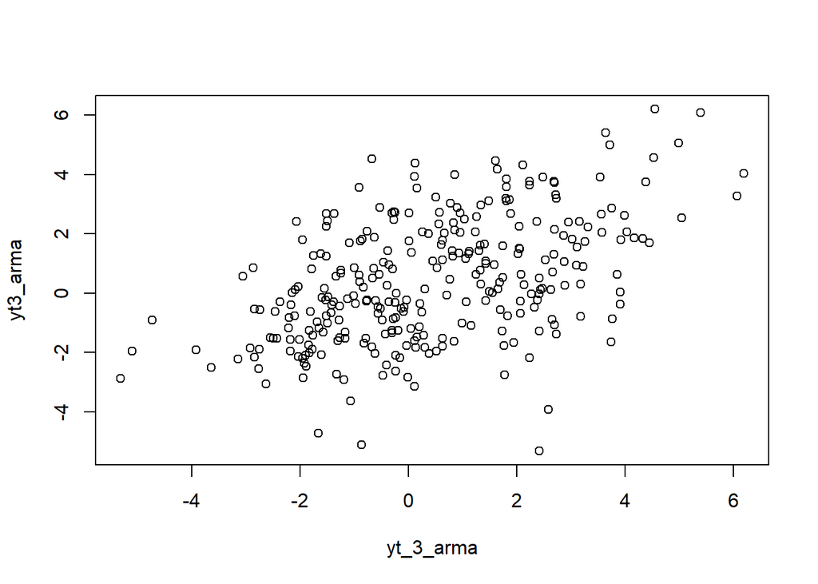

```r
plot(y=yt3_arma,x=yt_3_arma)
```

Berdasarkan scatterplot tersebut, terlihat bahwa cenderung terdapat hubungan positif lemah antara $Y_t$ dengan $Y_{t-3}$. Hal ini sesuai dengan teori yang ada

```r
cor(yt3_arma,yt_3_arma)
```

```
## [1] 0.4929514
```

Korelasi antara $Y_t$ dengan $Y_{t-3}$ dari hasil simulasi sebesar 0.4929514